# Titanic Dataset: Analysis Framework for High-Level Research Questions

# Research Question 2: Rule Application and Social Context

## Conceptual Framework

The second research question examines whether the stated priority rule (“women and children first”) was applied consistently or whether it depended on passengers’ social visibility (indicated by fare, title, class) and travel context (traveling alone, with family, or in larger groups). This question tests whether institutional norms operate uniformly or adapt under crowding and coordination challenges.

## Step 1: Construct Travel Context Variables

```r
# Create travel context variables
titanic_train_rq2 <- titanic_train %>%
  mutate(
    # Total family size on ship
    family_size = SibSp + Parch + 1,
    # Travel context classification
    travel_context = case_when(
      family_size == 1 ~ "Alone",
      family_size %in% 2:3 ~ "Small Family",
      family_size %in% 4:5 ~ "Medium Family",
      family_size > 5 ~ "Large Family"
    ),
    # Extract title from name
    title = str_extract(Name, "(?<=\\s)[A-Za-z]+(?=\\.)"),
    # Standardize titles (collapse rare ones)
    title_group = case_when(
      title %in% c("Mr") ~ "Mr",
      title %in% c("Mrs") ~ "Mrs",
      title %in% c("Miss") ~ "Miss",
      title %in% c("Master") ~ "Master",
      title %in% c("Ms", "Mlle", "Mme") ~ "Ms/Mlle/Mme",
      title %in% c("Dr", "Rev", "Col", "Major", "Capt") ~ "Professional/Military",
      is.na(title) ~ "Unknown",
      TRUE ~ "Other"
    )
  )

# Display travel context and title distributions
travel_context_dist <- titanic_train_rq2 %>%
  group_by(travel_context) %>%
  summarise(
    n = n(),
    pct = round(100 * n() / nrow(titanic_train_rq2), 1),
    .groups = "drop"
  )

travel_context_dist %>%
  kable(
    col.names = c("Travel Context", "Count", "Percent"),
    caption = "Distribution of travel context"
  )
```

Distribution of travel context

| Travel Context | Count | Percent |
| --- | --- | --- |
| Alone | 537 | 60.3 |
| Large Family | 47 | 5.3 |
| Medium Family | 44 | 4.9 |
| Small Family | 263 | 29.5 |

```r
# Title distribution
title_dist <- titanic_train_rq2 %>%
  group_by(title_group) %>%
  summarise(n = n(), pct = round(100 * n() / nrow(titanic_train_rq2), 1), .groups = "drop") %>%
  arrange(desc(n))

title_dist %>%
  kable(
    col.names = c("Title Group", "Count", "Percent"),
    caption = "Distribution of passenger titles"
  )
```

Distribution of passenger titles

| Title Group | Count | Percent |
| --- | --- | --- |
| Mr | 517 | 58.0 |
| Miss | 182 | 20.4 |
| Mrs | 125 | 14.0 |
| Master | 40 | 4.5 |
| Professional/Military | 18 | 2.0 |
| Other | 5 | 0.6 |
| Ms/Mlle/Mme | 4 | 0.4 |

We construct two key contextual variables: (1) **travel context** (alone vs. small/medium/large family groups), and (2) **title** (Mr, Mrs, Miss, Master, professional/military titles). Travel context is constructed from SibSp (siblings/spouses) and Parch (parents/children), indicating whether passengers traveled in isolation or as part of family networks. Titles serve as proxies for social role, visibility, and status—they indicate professional standing, marital status, and age expectations. These variables are essential to testing whether “women and children first” was applied uniformly or contingent on social visibility and family coordination.

## Step 2: Examine Women and Children Priority by Context

```r
# Calculate women & children survival by travel context
wcf_analysis <- titanic_train_rq2 %>%
  mutate(
    is_woman = Sex == "female" & Age >= 18,
    is_child = Age < 18,
    is_wcf_category = is_woman | is_child,
    wcf_status = if_else(is_wcf_category, "Women/Children", "Other (mostly men)")
  ) %>%
  group_by(travel_context, wcf_status) %>%
  summarise(
    n = n(),
    survived = sum(Survived, na.rm = TRUE),
    survival_rate = round(100 * mean(Survived, na.rm = TRUE), 1),
    .groups = "drop"
  )

# Display main results
wcf_analysis %>%
  kable(
    col.names = c("Travel Context", "Category", "N", "Survived", "Survival Rate (%)"),
    caption = "Women & Children First rule application by travel context"
  )
```

Women & Children First rule application by travel context

| Travel Context | Category | N | Survived | Survival Rate (%) |
| --- | --- | --- | --- | --- |
| Alone | Other (mostly men) | 292 | 50 | 17.1 |
| Alone | Women/Children | 112 | 80 | 71.4 |
| Alone | NA | 133 | 33 | 24.8 |
| Large Family | Other (mostly men) | 4 | 0 | 0.0 |
| Large Family | Women/Children | 36 | 7 | 19.4 |
| Large Family | NA | 7 | 0 | 0.0 |
| Medium Family | Other (mostly men) | 5 | 1 | 20.0 |
| Medium Family | Women/Children | 33 | 23 | 69.7 |
| Medium Family | NA | 6 | 0 | 0.0 |
| Small Family | Other (mostly men) | 94 | 19 | 20.2 |
| Small Family | Women/Children | 138 | 110 | 79.7 |
| Small Family | NA | 31 | 19 | 61.3 |

```r
# Calculate the gap within each travel context - simple approach
wcf_gap_by_context <- wcf_analysis %>%
  select(travel_context, wcf_status, survival_rate) %>%
  pivot_wider(
    names_from = wcf_status,
    values_from = survival_rate
  ) %>%
  mutate(
    gap = `Women/Children` - `Other (mostly men)`
  )

wcf_gap_by_context %>%
  select(travel_context, gap) %>%
  kable(
    col.names = c("Travel Context", "WCF Advantage (%)"),
    caption = "Magnitude of women & children priority by context"
  )
```

Magnitude of women & children priority by context

| Travel Context | WCF Advantage (%) |
| --- | --- |
| Alone | 54.3 |
| Large Family | 19.4 |
| Medium Family | 49.7 |
| Small Family | 59.5 |

This analysis examines whether the survival advantage of women and children (core to the “women and children first” norm) varied by travel context. If the rule operated uniformly, we would expect similar gender/age gaps across all travel contexts. Variation in these gaps—particularly lower gaps in large family groups—would suggest that coordination and group pressure influenced rule application.

## Step 3: Interaction with Social Visibility (Title and Fare)

```r
# Examine how title and fare modify the sex-survival relationship
visibility_analysis <- titanic_train_rq2 %>%
  filter(!is.na(title_group) & !is.na(Fare)) %>%
  mutate(
    fare_level = case_when(
      Fare >= 100 ~ "High (≥£100)",
      Fare >= 30 ~ "Medium (£30-100)",
      Fare >= 10 ~ "Low (£10-30)",
      TRUE ~ "Very Low (<£10)"
    )
  ) %>%
  group_by(Sex, title_group, fare_level) %>%
  summarise(
    n = n(),
    survival_rate = round(100 * mean(Survived, na.rm = TRUE), 1),
    .groups = "drop"
  ) %>%
  filter(n >= 5) # Only show cells with sufficient sample size

# Focus on a simplified view: Sex × Fare Level
sex_fare_survival <- titanic_train_rq2 %>%
  filter(!is.na(Fare) & !is.na(Sex)) %>%
  mutate(
    fare_level = case_when(
      Fare >= 100 ~ "High (≥£100)",
      Fare >= 30 ~ "Medium (£30-100)",
      Fare >= 10 ~ "Low (£10-30)",
      TRUE ~ "Very Low (<£10)"
    )
  ) %>%
  group_by(Sex, fare_level) %>%
  summarise(
    n = n(),
    survival_rate = round(100 * mean(Survived, na.rm = TRUE), 1),
    .groups = "drop"
  )

sex_fare_survival %>%
  pivot_wider(
    names_from = Sex,
    values_from = c(n, survival_rate)
  ) %>%
  kable(
    col.names = c("Fare Level", "Female N", "Female %", "Male N", "Male %"),
    caption = "Survival by sex stratified by fare level (social visibility proxy)"
  )
```

Survival by sex stratified by fare level (social visibility proxy)

[output not shown]

```r
# Calculate gender gap by fare level
gender_gap_by_fare <- sex_fare_survival %>%
  pivot_wider(
    names_from = Sex,
    values_from = survival_rate
  ) %>%
  mutate(
    gender_gap = female - male
  )

gender_gap_by_fare %>%
  select(fare_level, gender_gap) %>%
  kable(
    col.names = c("Fare Level", "Gender Gap (Female - Male %)"),
    caption = "Women & children priority varies by social visibility (fare/status)"
  )
```

Women & children priority varies by social visibility (fare/status)

[output not shown]

This stratified analysis reveals whether the gender survival advantage was uniform across social visibility levels. A key insight: if women at high fares had much higher survival than men at high fares, but women at low fares had only modest survival advantages (or none), this suggests that social visibility modified rule application. High-fare passengers would be more visible and prioritized; low-fare passengers would be less visible and the rule might not apply. This speaks to how institutional norms interact with practical constraints.

## Step 4: Statistical Test of Interaction Effects

```r
# Fit models with and without interaction terms
# Model 1: Main effects only
model_main <- glm(
  Survived ~ Sex + Age + Pclass + SibSp + Parch,
  family = binomial,
  data = titanic_train_rq2 %>% filter(!is.na(Age))
)

# Model 2: With interaction between Sex and Pclass (does WCF apply equally across classes?)
model_sex_class_interact <- glm(
  Survived ~ Sex * Pclass + Age + SibSp + Parch,
  family = binomial,
  data = titanic_train_rq2 %>% filter(!is.na(Age))
)

# Model 3: With interaction between Sex and travel context
model_data <- titanic_train_rq2 %>%
  filter(!is.na(Age)) %>%
  mutate(
    travel_context = factor(travel_context)
  )

model_sex_context_interact <- glm(
  Survived ~ Sex * travel_context + Age + Pclass,
  family = binomial,
  data = model_data
)

# Compare models using likelihood ratio test
lr_test_1 <- anova(model_main, model_sex_class_interact, test = "Chisq")
lr_test_2 <- anova(model_main, model_sex_context_interact, test = "Chisq")

cat("Likelihood Ratio Test: Sex × Class Interaction\n")
```

```
Likelihood Ratio Test: Sex × Class Interaction
```

```r
print(lr_test_1)
```

```
Analysis of Deviance Table

Model 1: Survived ~ Sex + Age + Pclass + SibSp + Parch
Model 2: Survived ~ Sex * Pclass + Age + SibSp + Parch
  Resid. Df Resid. Dev Df Deviance  Pr(>Chi)
1       708     636.62
2       707     614.14  1    22.48 2.124e-06 ***
---
Signif. codes:  0 '***' 0.001 '**' 0.01 '*' 0.05 '.' 0.1 ' ' 1
```

```r
cat("\n\nLikelihood Ratio Test: Sex × Travel Context Interaction\n")
```

```
Likelihood Ratio Test: Sex × Travel Context Interaction
```

```r
print(lr_test_2)
```

```
Analysis of Deviance Table

Model 1: Survived ~ Sex + Age + Pclass + SibSp + Parch
Model 2: Survived ~ Sex * travel_context + Age + Pclass
  Resid. Df Resid. Dev Df Deviance Pr(>Chi)
1       708     636.62
2       704     630.22  4   6.4052   0.1709
```

```r
cat("\n\nInterpretation:\n")
```

```
Interpretation:
```

```r
cat("P-value < 0.05 suggests that the Sex effect on survival depends on the moderating variable.\n")
```

```
P-value < 0.05 suggests that the Sex effect on survival depends on the moderating variable.
```

```r
cat("This would indicate that 'women and children first' was NOT applied uniformly.\n")
```

```
This would indicate that 'women and children first' was NOT applied uniformly.
```

These interaction models statistically test whether the sex-survival relationship depends on class or travel context. Significant interactions (p < 0.05) would indicate that the women and children first rule operated differently depending on social or structural context—supporting the hypothesis that rules adapt under constraints.

## Step 5: Visualization of Interaction Patterns

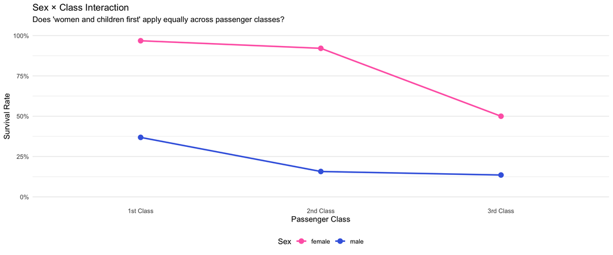

```r
# Prepare data for visualization
plot_data_sex_class <- titanic_train_rq2 %>%
  filter(!is.na(Sex) & !is.na(Pclass)) %>%
  mutate(
    Pclass = factor(Pclass, labels = c("1st Class", "2nd Class", "3rd Class"))
  ) %>%
  group_by(Pclass, Sex) %>%
  summarise(
    survival_rate = mean(Survived, na.rm = TRUE),
    n = n(),
    .groups = "drop"
  )

# Plot 1: Sex × Class
p1 <- ggplot(plot_data_sex_class, aes(x = Pclass, y = survival_rate, color = Sex, group = Sex)) +
  geom_point(size = 3) +
  geom_line(linewidth = 1) +
  scale_y_continuous(labels = scales::percent, limits = c(0, 1)) +
  scale_color_manual(values = c("female" = "#FF69B4", "male" = "#4169E1")) +
  theme_minimal() +
  theme(legend.position = "bottom", panel.grid.major.x = element_blank()) +
  labs(
    title = "Sex × Class Interaction",
    subtitle = "Does 'women and children first' apply equally across passenger classes?",
    x = "Passenger Class",
    y = "Survival Rate",
    color = "Sex"
  )

# Prepare data for context visualization
plot_data_sex_context <- titanic_train_rq2 %>%
  filter(!is.na(Sex) & !is.na(travel_context)) %>%
  group_by(travel_context, Sex) %>%
  summarise(
    survival_rate = mean(Survived, na.rm = TRUE),
    n = n(),
    .groups = "drop"
  ) %>%
  mutate(
    travel_context = factor(travel_context,
                            levels = c("Alone", "Small Family", "Medium Family", "Large Family"))
  )

# Plot 2: Sex × Travel Context
p2 <- ggplot(plot_data_sex_context, aes(x = travel_context, y = survival_rate, color = Sex, group = Sex)) +
  geom_point(size = 3) +
  geom_line(linewidth = 1) +
  scale_y_continuous(labels = scales::percent, limits = c(0, 1)) +
  scale_color_manual(values = c("female" = "#FF69B4", "male" = "#4169E1")) +
  theme_minimal() +
  theme(
    legend.position = "bottom",
    panel.grid.major.x = element_blank(),
    axis.text.x = element_text(angle = 45, hjust = 1)
  ) +
  labs(
    title = "Sex × Travel Context Interaction",
    subtitle = "Does gender advantage vary by whether traveling alone or with family?",
    x = "Travel Context",
    y = "Survival Rate",
    color = "Sex"
  )

# Display both plots
p1
```

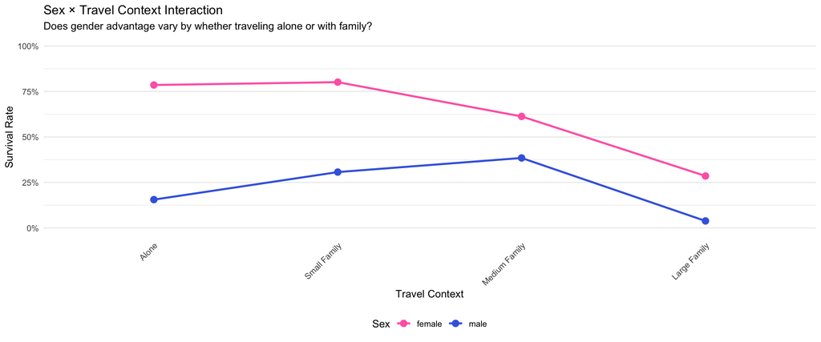

```r
p2
```

These interaction plots visualize whether the gender survival advantage (slope) varies across classes and travel contexts. Non-parallel lines indicate interactions: the sex effect is context-dependent. Convergence of lines at higher classes or larger families might suggest that coordination or class-based constraints modified rule application.

# Research Question 3: Missing Data as a Signal of Inequality

## Conceptual Framework

The third research question treats missing data not as a technical nuisance to be imputed away, but as potential evidence of historical inequality in record-keeping. Missing cabin numbers, ages, or embarkation ports might reflect that certain passengers were less visible to record-keepers, possibly due to class, gender, or travel context. Furthermore, if missingness is related to survival, imputation or deletion could bias conclusions about the Titanic disaster.

## Step 1: Characterize Missing Data Patterns

```r
# Examine missing data comprehensively - simpler approach
missing_summary <- data.frame(
  Variable = names(titanic_train),
  N_Missing = sapply(titanic_train, function(x) sum(is.na(x))),
  Pct_Missing = round(100 * sapply(titanic_train, function(x) mean(is.na(x))), 1)
) %>%
  arrange(desc(Pct_Missing))

missing_summary %>%
  kable(
    col.names = c("Variable", "N Missing", "Percent Missing"),
    caption = "Missing data summary for Titanic training set"
  )
```

Missing data summary for Titanic training set

|  | Variable | N Missing | Percent Missing |
| --- | --- | --- | --- |
| Cabin | Cabin | 687 | 77.1 |
| Age | Age | 177 | 19.9 |
| Embarked | Embarked | 2 | 0.2 |
| PassengerId | PassengerId | 0 | 0.0 |
| Survived | Survived | 0 | 0.0 |
| Pclass | Pclass | 0 | 0.0 |
| Name | Name | 0 | 0.0 |
| Sex | Sex | 0 | 0.0 |
| SibSp | SibSp | 0 | 0.0 |
| Parch | Parch | 0 | 0.0 |
| Ticket | Ticket | 0 | 0.0 |
| Fare | Fare | 0 | 0.0 |

```r
# Create missingness indicators
titanic_rq3 <- titanic_train %>%
  mutate(
    missing_cabin = is.na(Cabin),
    missing_age = is.na(Age),
    missing_embarked = is.na(Embarked),
    n_missing = (is.na(Cabin) + is.na(Age) + is.na(Embarked) + is.na(Fare))
  )

# Survival rate by missingness patterns
missing_pattern_survival <- titanic_rq3 %>%
  group_by(missing_cabin, missing_age) %>%
  summarise(
    n = n(),
    n_survived = sum(Survived, na.rm = TRUE),
    survival_rate = round(100 * mean(Survived, na.rm = TRUE), 1),
    .groups = "drop"
  ) %>%
  mutate(
    cabin_status = if_else(missing_cabin, "Missing", "Present"),
    age_status = if_else(missing_age, "Missing", "Present")
  ) %>%
  select(cabin_status, age_status, n, survival_rate)

missing_pattern_survival %>%
  kable(
    col.names = c("Cabin", "Age", "N", "Survival Rate (%)"),
    caption = "Survival rates by missing data pattern"
  )
```

Survival rates by missing data pattern

| Cabin | Age | N | Survival Rate (%) |
| --- | --- | --- | --- |
| Present | Present | 185 | 67.6 |
| Present | Missing | 19 | 57.9 |
| Missing | Present | 529 | 31.2 |
| Missing | Missing | 158 | 25.9 |

We begin by identifying which variables have substantial missing data. The Titanic dataset has notable missingness in **Cabin** (77.1%), **Age** (19.9%), and **Embarked** (0.2%). Our next step examines whether missingness is random or systematic—tied to class, gender, or other characteristics.

## Step 2: Is Missingness Related to Class and Demographics?

```r
# Examine whether missingness is associated with class
missing_by_class <- titanic_rq3 %>%
  group_by(Pclass) %>%
  summarise(
    n = n(),
    pct_missing_cabin = round(100 * mean(missing_cabin), 1),
    pct_missing_age = round(100 * mean(missing_age), 1),
    pct_missing_embarked = round(100 * mean(missing_embarked), 1),
    .groups = "drop"
  ) %>%
  mutate(
    Pclass = recode(Pclass, `1` = "1st Class", `2` = "2nd Class", `3` = "3rd Class")
  )

missing_by_class %>%
  kable(
    col.names = c("Class", "N", "% Missing Cabin", "% Missing Age", "% Missing Embarked"),
    caption = "Missing data patterns by passenger class"
  )
```

Missing data patterns by passenger class

| Class | N | % Missing Cabin | % Missing Age | % Missing Embarked |
| --- | --- | --- | --- | --- |
| 1st Class | 216 | 18.5 | 13.9 | 0.9 |
| 2nd Class | 184 | 91.3 | 6.0 | 0.0 |
| 3rd Class | 491 | 97.6 | 27.7 | 0.0 |

```r
# Chi-square test: Is missing cabin associated with class?
cabin_missing_by_class <- table(titanic_rq3$Pclass, titanic_rq3$missing_cabin)
chi_sq_cabin <- chisq.test(cabin_missing_by_class)

cat("Chi-square test: Cabin missingness × Class\n")
```

```
Chi-square test: Cabin missingness × Class
```

```r
cat("Chi-square =", round(chi_sq_cabin$statistic, 2),
    ", p-value =", round(chi_sq_cabin$p.value, 4), "\n")
```

```
Chi-square = 557.31 , p-value = 0
```

```r
if (chi_sq_cabin$p.value < 0.05) {
  cat("Result: SIGNIFICANT association. Cabin missingness is NOT random across classes.\n")
} else {
  cat("Result: No significant association. Cabin missingness appears random.\n")
}
```

```
Result: SIGNIFICANT association. Cabin missingness is NOT random across classes.
```

```r
# Missing data by gender
missing_by_sex <- titanic_rq3 %>%
  group_by(Sex) %>%
  summarise(
    n = n(),
    pct_missing_cabin = round(100 * mean(missing_cabin), 1),
    pct_missing_age = round(100 * mean(missing_age), 1),
    .groups = "drop"
  )

missing_by_sex %>%
  kable(
    col.names = c("Sex", "N", "% Missing Cabin", "% Missing Age"),
    caption = "Missing data patterns by passenger sex"
  )
```

Missing data patterns by passenger sex

| Sex | N | % Missing Cabin | % Missing Age |
| --- | --- | --- | --- |
| female | 314 | 69.1 | 16.9 |
| male | 577 | 81.5 | 21.5 |

This analysis asks: is missing data random (consistent across groups) or systematic (concentrated in particular classes or demographics)? If cabin data is missing more often for third-class passengers, this suggests record-keepers paid less attention to less-visible passengers—a form of inequality reflected in the data itself. Similar patterns for age or embarkation would reinforce this interpretation.